# 55-cv-comparison

In this notebook, we compare the effectiveness of the various model types based on the performance of cross validation metrics and backprojection.

### 0.0.1 Useful packages

### 0.0.2 Load data (if desired)

```r
mdl_list <- list('glmnet', 'nb', 'rf', 'xgb')
map(mdl_list, ~move_model_info(., 'load'))
```

# 1 Cross-validation metrics

## 1.1 Aggregate performance metrics

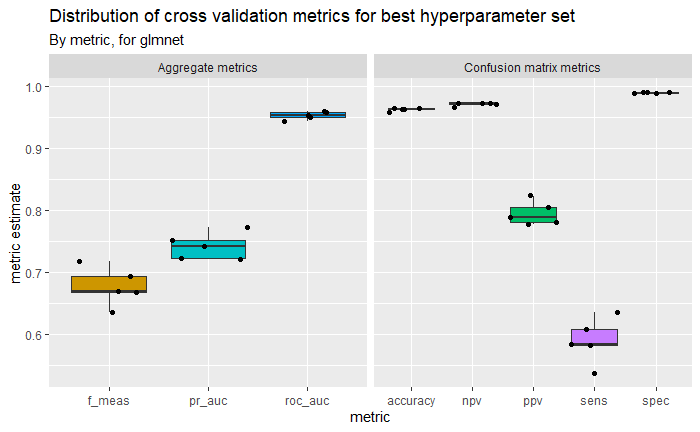

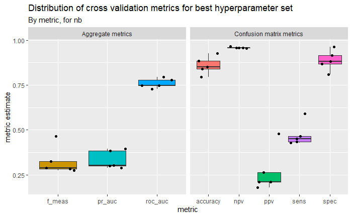

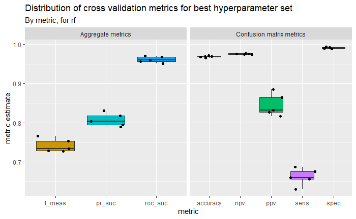

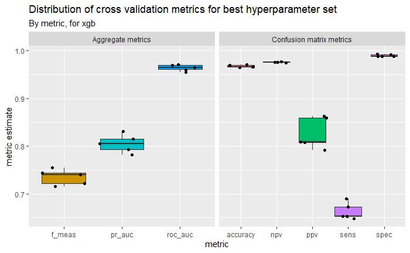

```r
#get best performance metrics for all models
best_fold_metrics <- mdl_list %>%
  map(~calculate_best_performance_metrics(get(str_c(., '_fold_metrics')),
                                          get(str_c('best_', ., '_params')), .))
```

```r
#name each element in list
names(best_fold_metrics) <- mdl_list

#aggregate all fold metrics and mutate all names
best_fold_metrics <- best_fold_metrics %>%
  map(~select(., id, .metric, .estimate, .config)) %>%
  map2_dfr(names(best_fold_metrics), function(df, mdl_name){mutate(df, modeltype=mdl_name)})
```

## 1.2 Basic performance overview

Let’s just look at the overall distribution of the metrics.

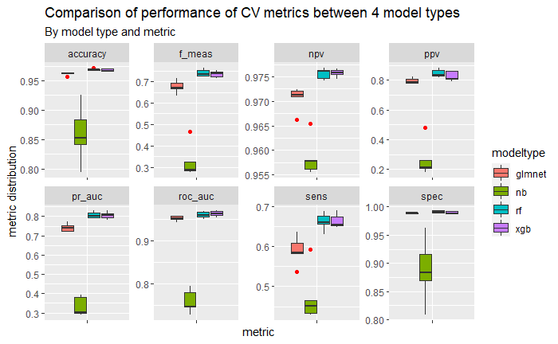

```r
best_fold_metrics %>%
  mutate(facet_val = if_else(.metric== 'roc_auc' | .metric=='pr_auc' | .metric=='f_meas', 'Aggregate metrics', 'Confusion matrix metrics')) %>%
  ggplot(aes(x=.metric, y=.estimate, fill=modeltype)) +
  geom_boxplot(outlier.colour = 'red', na.rm=TRUE) +
  facet_wrap(facet='.metric', scales='free', nrow=2) +
  labs(title='Comparison of performance of CV metrics between 4 model types',
       subtitle='By model type and metric',
       x='metric',
       y='metric distribution') +
  scale_x_discrete(labels=NULL)
```

In terms of cross-validation metrics, we can see that the logistic regression and the tree-based models are perform similarly and have relatively tightly distributed values. This means that any of these single models tends to have the same performance on slightly different datasets. On the other hand, naive bayes does tend to have relatively strong spread in the performance metrics, meaning that the model itself has substantial variance based on the data that it is given. This suggests that naive bayes may not be the best model for this data.

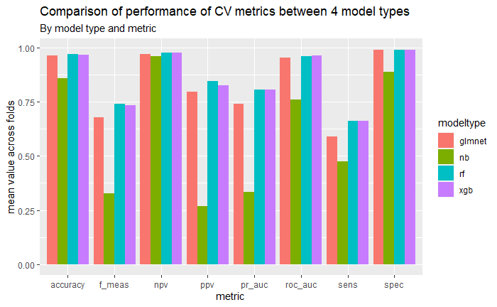

```r
best_fold_metrics %>%
  group_by(modeltype, .metric) %>%
  summarise(mean_value = mean(.estimate, na.rm = TRUE)) %>%
  ggplot(mapping = aes(x=.metric, y=mean_value, fill = modeltype)) +
    geom_col(position = "dodge") +
    labs(title='Comparison of performance of CV metrics between 4 model types',
       subtitle='By model type and metric',
       x='metric',
       y='mean value across folds')
```

```r
NA
```

Here, we can see the same plot as before, but as a comparison between the average values of these metrics over the cross-validation folds. We again see the challenges faced by naive bayes whereas the other models perform relatively similarly.

# 2 Training data

## 2.1 Basic performance overview

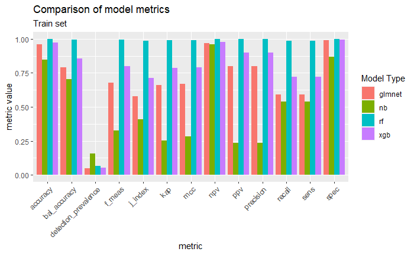

```r
#get list of prediction dataframes
model_preds_dfs <- mdl_list %>%
  map(~get(str_c(., '_final_fit'))) %>%
  map(~get_prediction_dataframes(., train_data))

#give list elements names
names(model_preds_dfs) <- mdl_list

#get aggregated training metrics
train_metrics <- model_preds_dfs %>%
  map(~summary(conf_mat(., particle_class, .pred_class))) %>%
  map2_dfr(names(model_preds_dfs), function(df, mdl_name){mutate(df, mdl_name=mdl_name)})

#plot
train_metrics %>%
  ggplot(aes(x=.metric, y=.estimate, fill=mdl_name))+
  geom_col(position='dodge') +
  labs(x='metric', y='metric value', title='Comparison of model metrics', subtitle='Train set', fill='Model Type') +
  theme(axis.text.x = element_text(angle = 45, hjust=1))
```

Re-predicting on the entire training set, we see again that naive bayes has challenges in contrast to the other models. We also see that here, the random forest dominates. In terms of the default threshold of 0.5, sensitivity is best by far with the random forest.

## 2.2 Compare ROCs

```
    === AUCs ===

     Model name Dataset ID Curve type       AUC
   1     glmnet          1        ROC 0.9535918
   2     glmnet          1        PRC 0.7487327
   3         nb          1        ROC 0.7812023
   4         nb          1        PRC 0.4041006
   5         rf          1        ROC 0.9999980
   6         rf          1        PRC 0.9999724
   7        xgb          1        ROC 0.9818538
   8        xgb          1        PRC 0.8806088

    === Input data ===

     Model name Dataset ID # of negatives # of positives
   1     glmnet          1          31377           2294
   2         nb          1          31377           2294
   3         rf          1          31377           2294
   4        xgb          1          31377           2294
```

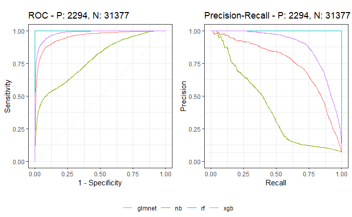

```r
#plot performance
plot_performance_curves(model_preds_dfs, unlist(mdl_list))
```

The ROC curves and AUC again suggest great performance for everything other than Naive Bayes, although the random forest again dominates. The performance of the random forest is so good that it is suspicious, and could suggest overtraining (poor generalization). This will be explored in the next section which evaluates the models on the holdout set.

## 2.3 Calibration Plots

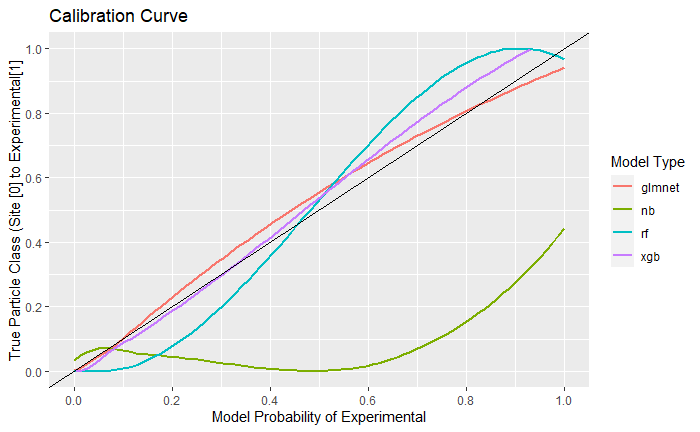

```r
#add model name
cal_df <- model_preds_dfs %>%
  map2_df(names(model_preds_dfs), function(df, mdl_name){mutate(df, mdl_name=mdl_name)})

#plot calibration curves
plot_calibration_curve(cal_df)
```

The calibration plots here show that the model is relatively well calibrated for all of the expected models (not Naive Bayes). Glmnet has the best calibration (closest to the diagonal line), and the tree based-models exhibit the standard s-shaped curve which is most pronounced in the random forest. The random forest may need a bit of additional calibration to accurately reflect probabilities rather than general scores.

# 3 Test data

## 3.1 Basic performance overview

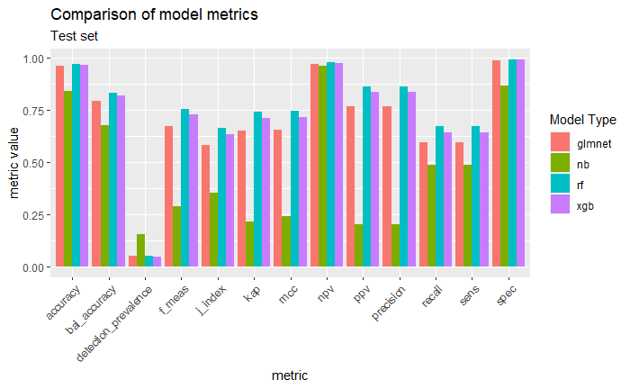

```r
#get list of prediction dataframes
model_test_preds_dfs <- mdl_list %>%
  map(~get(str_c(., '_final_fit'))) %>%
  map(~get_prediction_dataframes(., test_data))

#give list elements names
names(model_test_preds_dfs) <- mdl_list

#get aggregated metrics
test_metrics <- model_test_preds_dfs %>%
  map(~summary(conf_mat(., particle_class, .pred_class))) %>%
  map2_dfr(names(model_test_preds_dfs), function(df, mdl_name){mutate(df, mdl_name=mdl_name)})

#plot
test_metrics %>%
  ggplot(aes(x=.metric, y=.estimate, fill=mdl_name))+
  geom_col(position='dodge') +
  labs(x='metric', y='metric value', title='Comparison of model metrics', subtitle='Test set', fill='Model Type') +
  theme(axis.text.x = element_text(angle = 45, hjust=1))
```

```
    === AUCs ===

     Model name Dataset ID Curve type       AUC
   1     glmnet          1        ROC 0.9595709
   2     glmnet          1        PRC 0.7385052
   3         nb          1        ROC 0.7586969
   4         nb          1        PRC 0.3311665
   5         rf          1        ROC 0.9651799
   6         rf          1        PRC 0.8163986
   7        xgb          1        ROC 0.9657206
   8        xgb          1        PRC 0.8062457

    === Input data ===

     Model name Dataset ID # of negatives # of positives
   1     glmnet          1          10488            735
   2         nb          1          10488            735
   3         rf          1          10488            735
   4        xgb          1          10488            735
```

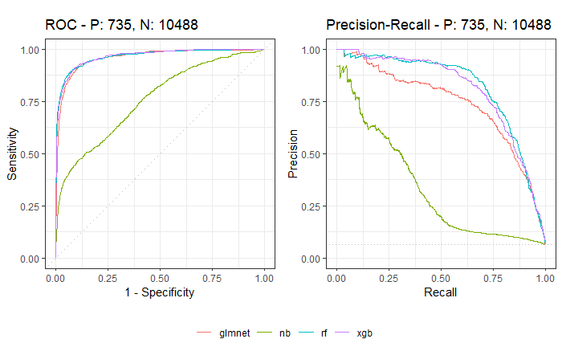

```r
#plot performance
plot_performance_curves(model_test_preds_dfs, unlist(mdl_list))
```

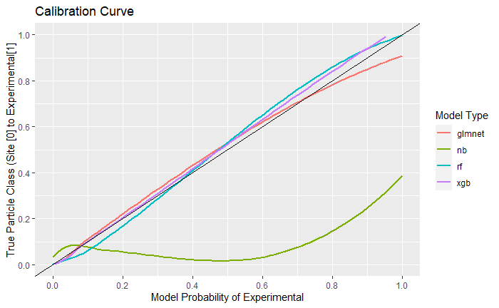

```r
#add model name
cal_test_df <- model_test_preds_dfs %>%
  map2_df(names(model_test_preds_dfs), function(df, mdl_name){mutate(df, mdl_name=mdl_name)})

#plot calibration curves
plot_calibration_curve(cal_test_df)
```

This is an extremely interesting plot that suggests that perhaps, we may be able to accept the outputs of almost all of the models (except Naive Bayes) to be probabilities rather than simply scores.

# 4 Save markdown file

```r
#fs::file_copy('55-cv-comparison.nb.html', './html_results/55-cv-comparison.nb.html', overwrite=TRUE)
```